# Part I - (Prosper Loan Dataset)

## Introduction

The dataset is a loan data named Prosper loan. The data contains 113937, and 81 variales. The main purpose is to deduced the variables that might affect the loa status ad also to get ideas aout their relationship using statistics and visualization.

## Preliminary Wrangling

```python
# import all packages and set plots to be embedded inline
import numpy as np
import pandas as pd
import matplotlib.pyplot as plt
import seaborn as sb
import warnings
warnings.filterwarnings("ignore")

%matplotlib inline
```

```python
#load dataset into a pandas dataframe, displaying five colums of the dataset
Loan = pd.read_csv('prosperLoanData.csv')
Loan.head()
```

|  | ListingKey | ListingNumber | ListingCreationDate | CreditGrade | Term | LoanStatus | ClosedDate | BorrowerAPR | BorrowerRate | LenderYield | ... | LP_ServiceFees | LP_CollectionFees | LP_GrossPrincipalLoss | LP_NetPrincipalLoss | LP_NonPrincipalRecoverypayments | PercentFunded | Recommendations | InvestmentFromFriendsCount | InvestmentFromFriendsAmount | Investors |
| --- | --- | --- | --- | --- | --- | --- | --- | --- | --- | --- | --- | --- | --- | --- | --- | --- | --- | --- | --- | --- | --- |
| 0 | 1021339766868145413AB3B | 193129 | 2007-08-26 19:09:29.263000000 | C | 36 | Completed | 2009-08-14 00:00:00 | 0.16516 | 0.1580 | 0.1380 | ... | -133.18 | 0.0 | 0.0 | 0.0 | 0.0 | 1.0 | 0 | 0 | 0.0 | 258 |
| 1 | 10273602499503308B223C1 | 1209647 | 2014-02-27 08:28:07.900000000 | NaN | 36 | Current | NaN | 0.12016 | 0.0920 | 0.0820 | ... | 0.00 | 0.0 | 0.0 | 0.0 | 0.0 | 1.0 | 0 | 0 | 0.0 | 1 |
| 2 | 0EE9337825851032864889A | 81716 | 2007-01-05 15:00:47.090000000 | HR | 36 | Completed | 2009-12-17 00:00:00 | 0.28269 | 0.2750 | 0.2400 | ... | -24.20 | 0.0 | 0.0 | 0.0 | 0.0 | 1.0 | 0 | 0 | 0.0 | 41 |
| 3 | 0EF5356002482715299901A | 658116 | 2012-10-22 11:02:35.010000000 | NaN | 36 | Current | NaN | 0.12528 | 0.0974 | 0.0874 | ... | -108.01 | 0.0 | 0.0 | 0.0 | 0.0 | 1.0 | 0 | 0 | 0.0 | 158 |
| 4 | 0F023589499656230C5E3E2 | 909464 | 2013-09-14 18:38:39.097000000 | NaN | 36 | Current | NaN | 0.24614 | 0.2085 | 0.1985 | ... | -60.27 | 0.0 | 0.0 | 0.0 | 0.0 | 1.0 | 0 | 0 | 0.0 | 20 |

5 rows × 81 columns

```python
Loan.shape
```

```
(113937, 81)
```

```python
Loan.dtypes
```

```
ListingKey                      object
ListingNumber                    int64
ListingCreationDate             object
CreditGrade                     object
Term                             int64
                                ...
PercentFunded                  float64
Recommendations                  int64
InvestmentFromFriendsCount       int64
InvestmentFromFriendsAmount    float64
Investors                        int64
Length: 81, dtype: object
```

```python
Loan.info()
```

```
<class 'pandas.core.frame.DataFrame'>
RangeIndex: 113937 entries, 0 to 113936
Data columns (total 81 columns):
 #   Column                               Non-Null Count   Dtype
---  ------                               --------------   -----
 0   ListingKey                           113937 non-null  object
 1   ListingNumber                        113937 non-null  int64
 2   ListingCreationDate                  113937 non-null  object
 3   CreditGrade                          28953 non-null   object
 4   Term                                 113937 non-null  int64
 5   LoanStatus                           113937 non-null  object
 6   ClosedDate                           55089 non-null   object
 7   BorrowerAPR                          113912 non-null  float64
 8   BorrowerRate                         113937 non-null  float64
 9   LenderYield                          113937 non-null  float64
```

[output cut: 73 more lines]

#### Issue 1:

#### Define

Drop coulums that are not needed.

#### Code

```python
#subseting the dataframe by selecting features not needed/interested

Loan.drop(['ListingKey', 'ListingNumber', 'ListingCreationDate','CreditGrade', 'ClosedDate','EstimatedEffectiveYield','EstimatedLoss','EstimatedReturn','ProsperRating (numeric)',
'ProsperRating (Alpha)', 'ProsperScore','GroupKey','CurrentlyInGroup','DateCreditPulled','EmploymentStatusDuration',
'CreditScoreRangeLower','CreditScoreRangeUpper','FirstRecordedCreditLine', 'CurrentCreditLines', 'OpenCreditLines',
'OpenCreditLines','TotalCreditLinespast7years','OpenRevolvingAccounts','OpenRevolvingMonthlyPayment','InquiriesLast6Months',
'TotalInquiries','CurrentDelinquencies','AmountDelinquent','DelinquenciesLast7Years','PublicRecordsLast10Years',
'PublicRecordsLast12Months','RevolvingCreditBalance','BankcardUtilization', 'TradesOpenedLast6Months',
'AvailableBankcardCredit','LoanOriginationQuarter','LoanKey','TotalProsperLoans','TotalProsperPaymentsBilled',
'OnTimeProsperPayments','ProsperPaymentsLessThanOneMonthLate','ProsperPaymentsOneMonthPlusLate','ProsperPrincipalOutstanding',
'ProsperPrincipalBorrowed','IncomeVerifiable','ScorexChangeAtTimeOfListing','LoanCurrentDaysDelinquent',
'LoanFirstDefaultedCycleNumber','LoanMonthsSinceOrigination','LoanOriginationDate', 'MemberKey','LP_CustomerPayments',
'LP_CustomerPrincipalPayments','LP_InterestandFees','LP_ServiceFees', 'LP_CollectionFees','LP_GrossPrincipalLoss',
'LP_NetPrincipalLoss','LP_NonPrincipalRecoverypayments','Recommendations','InvestmentFromFriendsCount',
'InvestmentFromFriendsAmount'], axis = 1, inplace = True)
```

#### Test

```python
#displaying the information
Loan.info()
```

```
<class 'pandas.core.frame.DataFrame'>
RangeIndex: 113937 entries, 0 to 113936
Data columns (total 20 columns):
 #   Column                              Non-Null Count   Dtype
---  ------                              --------------   -----
 0   Term                                113937 non-null  int64
 1   LoanStatus                          113937 non-null  object
 2   BorrowerAPR                         113912 non-null  float64
 3   BorrowerRate                        113937 non-null  float64
 4   LenderYield                         113937 non-null  float64
 5   ListingCategory (numeric)           113937 non-null  int64
 6   BorrowerState                       108422 non-null  object
 7   Occupation                          110349 non-null  object
 8   EmploymentStatus                    111682 non-null  object
 9   IsBorrowerHomeowner                 113937 non-null  bool
 10  TotalTrades                         106393 non-null  float64
 11  TradesNeverDelinquent (percentage)  106393 non-null  float64
 12  DebtToIncomeRatio                   105383 non-null  float64
 13  IncomeRange                         113937 non-null  object
 14  StatedMonthlyIncome                 113937 non-null  float64
 15  LoanNumber                          113937 non-null  int64
 16  LoanOriginalAmount                  113937 non-null  int64
 17  MonthlyLoanPayment                  113937 non-null  float64
 18  PercentFunded                       113937 non-null  float64
 19  Investors                           113937 non-null  int64
dtypes: bool(1), float64(9), int64(5), object(5)
memory usage: 16.6+ MB
```

#### Issue 2

#### Define

##### Remove all duplicated rows in the dataset

#### code

```python
#checking for duplicate
Loan.duplicated().value_counts()
```

```
False    113066
True        871
dtype: int64
```

```python
#dropping all duplicate and renaming the dataset
LoanP = Loan.drop_duplicates()
```

#### Test

```python
LoanP.duplicated().value_counts()
```

```
False    113066
dtype: int64
```

Dropping all missing and Null values the dataset

#### Issue 3

#### Define

Dropping all missing and Null values the dataset

#### Code

```python
#o check for all null values
LoanP.isnull().sum()
```

```
Term                                     0
LoanStatus                               0
BorrowerAPR                             25
BorrowerRate                             0
LenderYield                              0
ListingCategory (numeric)                0
BorrowerState                         5515
Occupation                            3529
EmploymentStatus                      2255
IsBorrowerHomeowner                      0
TotalTrades                           7544
TradesNeverDelinquent (percentage)    7544
DebtToIncomeRatio                     8472
IncomeRange                              0
StatedMonthlyIncome                      0
LoanNumber                               0
LoanOriginalAmount                       0
MonthlyLoanPayment                       0
PercentFunded                            0
Investors                                0
dtype: int64
```

```python
# drop all null values
LoanP = Loan.dropna()
```

#### Test

```python
LoanP.isna().sum()
```

```
Term                                  0
LoanStatus                            0
BorrowerAPR                           0
BorrowerRate                          0
LenderYield                           0
ListingCategory (numeric)             0
BorrowerState                         0
Occupation                            0
EmploymentStatus                      0
IsBorrowerHomeowner                   0
TotalTrades                           0
TradesNeverDelinquent (percentage)    0
DebtToIncomeRatio                     0
IncomeRange                           0
StatedMonthlyIncome                   0
LoanNumber                            0
LoanOriginalAmount                    0
MonthlyLoanPayment                    0
PercentFunded                         0
Investors                             0
dtype: int64
```

```python
LoanP.head(30)
```

|  | Term | LoanStatus | BorrowerAPR | BorrowerRate | LenderYield | ListingCategory (numeric) | BorrowerState | Occupation | EmploymentStatus | IsBorrowerHomeowner | TotalTrades | TradesNeverDelinquent (percentage) | DebtToIncomeRatio | IncomeRange | StatedMonthlyIncome | LoanNumber | LoanOriginalAmount | MonthlyLoanPayment | PercentFunded | Investors |
| --- | --- | --- | --- | --- | --- | --- | --- | --- | --- | --- | --- | --- | --- | --- | --- | --- | --- | --- | --- | --- |
| 0 | 36 | Completed | 0.16516 | 0.1580 | 0.1380 | 0 | CO | Other | Self-employed | True | 11.0 | 0.81 | 0.17 | $25,000-49,999 | 3083.333333 | 19141 | 9425 | 330.43 | 1.0000 | 258 |
| 1 | 36 | Current | 0.12016 | 0.0920 | 0.0820 | 2 | CO | Professional | Employed | False | 29.0 | 1.00 | 0.18 | $50,000-74,999 | 6125.000000 | 134815 | 10000 | 318.93 | 1.0000 | 1 |
| 3 | 36 | Current | 0.12528 | 0.0974 | 0.0874 | 16 | GA | Skilled Labor | Employed | True | 26.0 | 0.76 | 0.15 | $25,000-49,999 | 2875.000000 | 77296 | 10000 | 321.45 | 1.0000 | 158 |
| 4 | 36 | Current | 0.24614 | 0.2085 | 0.1985 | 2 | MN | Executive | Employed | True | 39.0 | 0.95 | 0.26 | $100,000+ | 9583.333333 | 102670 | 15000 | 563.97 | 1.0000 | 20 |
| 5 | 60 | Current | 0.15425 | 0.1314 | 0.1214 | 1 | NM | Professional | Employed | True | 47.0 | 1.00 | 0.36 | $100,000+ | 8333.333333 | 123257 | 15000 | 342.37 | 1.0000 | 1 |
| 6 | 36 | Current | 0.31032 | 0.2712 | 0.2612 | 1 | KS | Sales - Retail | Employed | False | 16.0 | 0.68 | 0.27 | $25,000-49,999 | 2083.333333 | 88353 | 3000 | 122.67 | 1.0000 | 1 |
| 7 | 36 | Current | 0.23939 | 0.2019 | 0.1919 | 2 | CA | Laborer | Employed | False | 10.0 | 0.80 | 0.24 | $25,000-49,999 | 3355.750000 | 90051 | 10000 | 372.60 | 1.0000 | 1 |
| 8 | 36 | Current | 0.07620 | 0.0629 | 0.0529 | 7 | IL | Food Service | Employed | True | 29.0 | 1.00 | 0.25 | $25,000-49,999 | 3333.333333 | 121268 | 10000 | 305.54 | 1.0000 | 1 |
| 9 | 36 | Current | 0.07620 | 0.0629 | 0.0529 | 7 | IL | Food Service | Employed | True | 29.0 | 1.00 | 0.25 | $25,000-49,999 | 3333.333333 | 121268 | 10000 | 305.54 | 1.0000 | 1 |
| 10 | 60 | Current | 0.27462 | 0.2489 | 0.2389 | 1 | MD | Fireman | Employed | False | 47.0 | 0.72 | 0.12 | $75,000-99,999 | 7500.000000 | 65946 | 13500 | 395.37 | 1.0000 | 19 |
| 12 | 36 | Past Due (1-15 days) | 0.17969 | 0.1435 | 0.1335 | 1 | AL | Sales - Retail | Employed | False | 20.0 | 1.00 | 0.18 | $25,000-49,999 | 2416.666667 | 125045 | 4000 | 137.39 | 1.0000 | 1 |
| 13 | 36 | Current | 0.13138 | 0.1034 | 0.0934 | 1 | AZ | Construction | Employed | True | 18.0 | 0.94 | 0.09 | $50,000-74,999 | 5833.333333 | 96202 | 8500 | 275.63 | 1.0000 | 171 |
| 14 | 60 | Current | 0.11695 | 0.0949 | 0.0849 | 1 | VA | Computer Programmer | Employed | False | 48.0 | 1.00 | 0.20 | $100,000+ | 10833.333333 | 90060 | 19330 | 415.37 | 0.7731 | 371 |
| 15 | 36 | Defaulted | 0.35797 | 0.3177 | 0.3077 | 13 | FL | Other | Other | True | 17.0 | 0.94 | 0.49 | $50,000-74,999 | 5500.000000 | 63982 | 4000 | 173.71 | 1.0000 | 10 |
| 16 | 60 | Current | 0.30748 | 0.2809 | 0.2709 | 6 | CA | Professional | Full-time | True | 25.0 | 0.84 | 0.15 | $75,000-99,999 | 8291.666667 | 95921 | 4000 | 124.76 | 1.0000 | 8 |
| 18 | 36 | Current | 0.12528 | 0.0974 | 0.0874 | 1 | PA | Sales - Commission | Employed | False | 32.0 | 1.00 | 0.24 | $75,000-99,999 | 6250.000000 | 85974 | 15000 | 482.18 | 1.0000 | 303 |
| 19 | 60 | Current | 0.24754 | 0.2225 | 0.2125 | 1 | OR | Laborer | Employed | False | 20.0 | 1.00 | 0.41 | $25,000-49,999 | 3075.000000 | 105323 | 6500 | 180.45 | 1.0000 | 1 |
| 20 | 36 | Current | 0.16732 | 0.1314 | 0.1214 | 1 | MN | Retail Management | Employed | True | 21.0 | 0.95 | 0.20 | $50,000-74,999 | 5166.666667 | 118374 | 14000 | 472.66 | 1.0000 | 1 |
| 21 | 36 | Completed | 0.21488 | 0.2075 | 0.1975 | 0 | MI | Professional | Full-time | False | 6.0 | 0.37 | 0.09 | $25,000-49,999 | 3750.000000 | 23565 | 3000 | 112.64 | 1.0000 | 53 |
| 22 | 36 | Current | 0.35356 | 0.3134 | 0.3034 | 1 | NY | Other | Other | False | 17.0 | 0.76 | 9.20 | $1-24,999 | 118.333333 | 84693 | 4000 | 172.76 | 1.0000 | 94 |
| 23 | 36 | Defaulted | 0.28032 | 0.2419 | 0.2319 | 15 | IL | Skilled Labor | Employed | False | 22.0 | 1.00 | 0.39 | $25,000-49,999 | 2500.000000 | 89204 | 2000 | 78.67 | 1.0000 | 30 |
| 24 | 36 | Current | 0.19859 | 0.1620 | 0.1520 | 1 | LA | Other | Employed | True | 47.0 | 0.91 | 0.16 | $25,000-49,999 | 2333.333333 | 122689 | 4000 | 141.02 | 1.0000 | 1 |
| 25 | 36 | Current | 0.30182 | 0.2629 | 0.2529 | 15 | CA | Engineer - Mechanical | Employed | False | 10.0 | 0.72 | 0.12 | $75,000-99,999 | 6974.000000 | 105431 | 4000 | 161.78 | 1.0000 | 3 |
| 26 | 60 | Completed | 0.30748 | 0.2809 | 0.2709 | 1 | NY | Sales - Commission | Employed | False | 10.0 | 1.00 | 0.11 | $25,000-49,999 | 3885.916667 | 85538 | 4000 | 124.76 | 1.0000 | 37 |
| 27 | 36 | Completed | 0.11296 | 0.0920 | 0.0820 | 1 | CO | Executive | Full-time | True | 40.0 | 1.00 | 0.26 | $75,000-99,999 | 6666.666667 | 43110 | 4000 | 0.00 | 1.0000 | 121 |
| 28 | 36 | Current | 0.20268 | 0.1660 | 0.1560 | 2 | PA | Military Enlisted | Employed | True | 5.0 | 1.00 | 0.12 | $25,000-49,999 | 3600.000000 | 110393 | 10000 | 354.54 | 1.0000 | 1 |
| 29 | 36 | Current | 0.15223 | 0.1239 | 0.1139 | 1 | LA | Other | Employed | True | 47.0 | 0.97 | 0.32 | $100,000+ | 10416.666667 | 127405 | 35000 | 1169.03 | 1.0000 | 1 |
| 30 | 36 | Completed | 0.12782 | 0.0999 | 0.0899 | 20 | CA | Other | Employed | False | 18.0 | 0.72 | 0.11 | $25,000-49,999 | 3750.000000 | 60054 | 10000 | 322.62 | 1.0000 | 30 |
| 31 | 36 | Current | 0.35797 | 0.3177 | 0.3077 | 2 | WI | Other | Other | False | 20.0 | 0.60 | 0.04 | $25,000-49,999 | 2250.000000 | 75030 | 2000 | 86.85 | 1.0000 | 24 |
| 32 | 36 | Current | 0.16324 | 0.1274 | 0.1174 | 1 | NY | Clerical | Employed | True | 29.0 | 0.96 | 0.22 | $75,000-99,999 | 7000.000000 | 127880 | 25000 | 839.22 | 1.0000 | 1 |

```python
LoanP.tail(30)
```

|  | Term | LoanStatus | BorrowerAPR | BorrowerRate | LenderYield | ListingCategory (numeric) | BorrowerState | Occupation | EmploymentStatus | IsBorrowerHomeowner | TotalTrades | TradesNeverDelinquent (percentage) | DebtToIncomeRatio | IncomeRange | StatedMonthlyIncome | LoanNumber | LoanOriginalAmount | MonthlyLoanPayment | PercentFunded | Investors |
| --- | --- | --- | --- | --- | --- | --- | --- | --- | --- | --- | --- | --- | --- | --- | --- | --- | --- | --- | --- | --- |
| 113901 | 60 | Current | 0.15016 | 0.1274 | 0.1174 | 1 | GA | Executive | Employed | True | 21.0 | 1.00 | 0.30 | $50,000-74,999 | 6000.000000 | 117831 | 20000 | 452.40 | 1.0 | 1 |
| 113904 | 36 | Chargedoff | 0.24753 | 0.2400 | 0.2300 | 0 | WA | Nurse (LPN) | Full-time | True | 37.0 | 0.89 | 0.55 | $50,000-74,999 | 4166.666667 | 21278 | 10000 | 392.33 | 1.0 | 79 |
| 113905 | 36 | Chargedoff | 0.35797 | 0.3177 | 0.3077 | 1 | NJ | Other | Employed | True | 27.0 | 0.81 | 0.35 | $25,000-49,999 | 3250.000000 | 57055 | 4000 | 173.71 | 1.0 | 69 |
| 113906 | 36 | Completed | 0.07479 | 0.0680 | 0.0680 | 3 | GA | Professional | Full-time | True | 18.0 | 1.00 | 0.12 | $50,000-74,999 | 5916.666667 | 29350 | 3001 | 92.39 | 1.0 | 135 |
| 113907 | 36 | Current | 0.35356 | 0.3134 | 0.3034 | 1 | AZ | Sales - Retail | Employed | False | 18.0 | 0.85 | 0.40 | $25,000-49,999 | 2166.666667 | 110842 | 4000 | 172.76 | 1.0 | 3 |
| 113909 | 60 | Current | 0.27554 | 0.2498 | 0.2398 | 2 | FL | Clerical | Employed | True | 15.0 | 1.00 | 0.24 | $25,000-49,999 | 3333.333333 | 74552 | 6000 | 176.04 | 1.0 | 9 |
| 113910 | 36 | Current | 0.32446 | 0.2850 | 0.2750 | 1 | TX | Executive | Employed | False | 24.0 | 0.83 | 0.18 | $100,000+ | 18756.000000 | 129056 | 4000 | 166.54 | 1.0 | 1 |
| 113911 | 36 | Current | 0.25330 | 0.2155 | 0.2055 | 14 | MD | Other | Employed | False | 25.0 | 0.69 | 0.29 | $25,000-49,999 | 3333.333333 | 118059 | 10000 | 379.58 | 1.0 | 1 |
| 113912 | 36 | Current | 0.06726 | 0.0605 | 0.0505 | 2 | MN | Scientist | Employed | False | 36.0 | 1.00 | 0.20 | $25,000-49,999 | 2500.000000 | 121950 | 4000 | 121.78 | 1.0 | 1 |
| 113913 | 36 | Completed | 0.12410 | 0.1030 | 0.0930 | 1 | WA | Analyst | Full-time | True | 52.0 | 1.00 | 0.25 | $100,000+ | 9750.000000 | 42342 | 8000 | 259.27 | 1.0 | 265 |
| 113915 | 36 | Completed | 0.22237 | 0.2000 | 0.1900 | 7 | MA | Other | Full-time | True | 24.0 | 0.79 | 0.26 | $50,000-74,999 | 4416.666667 | 35060 | 3000 | 1.57 | 1.0 | 135 |
| 113916 | 36 | Current | 0.33286 | 0.2932 | 0.2832 | 13 | FL | Professional | Employed | False | 20.0 | 0.75 | 0.15 | $50,000-74,999 | 4583.333333 | 78237 | 4000 | 168.32 | 1.0 | 87 |
| 113917 | 36 | Current | 0.32446 | 0.2850 | 0.2750 | 1 | OH | Clerical | Employed | False | 15.0 | 0.78 | 0.40 | $1-24,999 | 1916.666667 | 118539 | 4000 | 166.54 | 1.0 | 1 |
| 113918 | 36 | Defaulted | 0.12201 | 0.1080 | 0.0980 | 4 | CA | Social Worker | Full-time | True | 40.0 | 0.95 | 0.39 | $50,000-74,999 | 5583.333333 | 33438 | 7000 | 228.51 | 1.0 | 173 |
| 113919 | 36 | Current | 0.27285 | 0.2346 | 0.2246 | 2 | IL | Other | Other | True | 14.0 | 1.00 | 0.22 | $25,000-49,999 | 2500.000000 | 90395 | 4000 | 155.80 | 1.0 | 1 |
| 113920 | 36 | Current | 0.35356 | 0.3134 | 0.3034 | 1 | NJ | Retail Management | Employed | True | 18.0 | 0.94 | 0.25 | $50,000-74,999 | 5208.333333 | 92986 | 4000 | 172.76 | 1.0 | 1 |
| 113922 | 36 | Completed | 0.15094 | 0.1295 | 0.1195 | 5 | GA | Other | Full-time | True | 14.0 | 0.78 | 0.18 | $50,000-74,999 | 5250.000000 | 35641 | 5000 | 168.35 | 1.0 | 145 |
| 113923 | 36 | Completed | 0.22378 | 0.2089 | 0.1989 | 1 | MS | Clergy | Full-time | True | 44.0 | 0.89 | 0.57 | $25,000-49,999 | 3966.666667 | 36931 | 8000 | 300.95 | 1.0 | 270 |
| 113924 | 60 | Current | 0.17317 | 0.1499 | 0.1399 | 13 | WA | Other | Employed | False | 11.0 | 0.72 | 0.17 | $25,000-49,999 | 3208.333333 | 76763 | 5000 | 118.92 | 1.0 | 83 |
| 113925 | 36 | Current | 0.31032 | 0.2712 | 0.2612 | 1 | NY | Homemaker | Employed | False | 18.0 | 1.00 | 0.28 | $25,000-49,999 | 2333.333333 | 89987 | 4000 | 163.56 | 1.0 | 1 |
| 113927 | 36 | Completed | 0.07469 | 0.0679 | 0.0579 | 4 | WA | Executive | Full-time | True | 17.0 | 1.00 | 0.06 | $100,000+ | 10333.333333 | 30797 | 4292 | 132.11 | 1.0 | 194 |
| 113928 | 36 | Completed | 0.22362 | 0.1899 | 0.1799 | 3 | CO | Other | Full-time | False | 15.0 | 1.00 | 0.27 | $25,000-49,999 | 2333.333333 | 50237 | 2000 | 73.30 | 1.0 | 25 |
| 113929 | 36 | Completed | 0.30285 | 0.2639 | 0.2539 | 2 | FL | Accountant/CPA | Employed | False | 11.0 | 0.75 | 0.05 | $50,000-74,999 | 4333.333333 | 95171 | 2500 | 101.25 | 1.0 | 26 |
| 113930 | 36 | Current | 0.20053 | 0.1639 | 0.1539 | 1 | IN | Professional | Employed | True | 30.0 | 0.96 | 0.20 | $75,000-99,999 | 6250.000000 | 95132 | 3000 | 106.05 | 1.0 | 52 |
| 113931 | 60 | Current | 0.15016 | 0.1274 | 0.1174 | 3 | IL | Analyst | Employed | False | 18.0 | 1.00 | 0.28 | $75,000-99,999 | 8146.666667 | 128416 | 25000 | 565.50 | 1.0 | 1 |
| 113932 | 36 | Current | 0.22354 | 0.1864 | 0.1764 | 1 | IL | Food Service Management | Employed | True | 37.0 | 0.83 | 0.13 | $50,000-74,999 | 4333.333333 | 88485 | 10000 | 364.74 | 1.0 | 1 |
| 113933 | 36 | FinalPaymentInProgress | 0.13220 | 0.1110 | 0.1010 | 7 | PA | Professional | Employed | True | 39.0 | 0.92 | 0.11 | $75,000-99,999 | 8041.666667 | 55801 | 2000 | 65.57 | 1.0 | 22 |
| 113934 | 60 | Current | 0.23984 | 0.2150 | 0.2050 | 1 | TX | Other | Employed | True | 25.0 | 1.00 | 0.51 | $25,000-49,999 | 2875.000000 | 123122 | 10000 | 273.35 | 1.0 | 119 |
| 113935 | 60 | Completed | 0.28408 | 0.2605 | 0.2505 | 2 | GA | Food Service | Full-time | True | 19.0 | 0.80 | 0.48 | $25,000-49,999 | 3875.000000 | 56401 | 15000 | 449.55 | 1.0 | 274 |
| 113936 | 36 | Current | 0.13189 | 0.1039 | 0.0939 | 1 | NY | Professor | Employed | False | 36.0 | 0.75 | 0.23 | $50,000-74,999 | 4583.333333 | 127508 | 2000 | 64.90 | 1.0 | 1 |

```python
LoanP.shape
```

```
(94883, 20)
```

```python
LoanP.info()
```

```
<class 'pandas.core.frame.DataFrame'>
Int64Index: 94883 entries, 0 to 113936
Data columns (total 20 columns):
 #   Column                              Non-Null Count  Dtype
---  ------                              --------------  -----
 0   Term                                94883 non-null  int64
 1   LoanStatus                          94883 non-null  object
 2   BorrowerAPR                         94883 non-null  float64
 3   BorrowerRate                        94883 non-null  float64
 4   LenderYield                         94883 non-null  float64
 5   ListingCategory (numeric)           94883 non-null  int64
 6   BorrowerState                       94883 non-null  object
 7   Occupation                          94883 non-null  object
 8   EmploymentStatus                    94883 non-null  object
 9   IsBorrowerHomeowner                 94883 non-null  bool
 10  TotalTrades                         94883 non-null  float64
 11  TradesNeverDelinquent (percentage)  94883 non-null  float64
 12  DebtToIncomeRatio                   94883 non-null  float64
 13  IncomeRange                         94883 non-null  object
 14  StatedMonthlyIncome                 94883 non-null  float64
 15  LoanNumber                          94883 non-null  int64
 16  LoanOriginalAmount                  94883 non-null  int64
 17  MonthlyLoanPayment                  94883 non-null  float64
 18  PercentFunded                       94883 non-null  float64
 19  Investors                           94883 non-null  int64
dtypes: bool(1), float64(9), int64(5), object(5)
memory usage: 14.6+ MB
```

### What is the structure of your dataset?

The dataset contains 94,883 loans with 20 features.

### What is/are the main feature(s) of interest in your dataset?

I am interested to explore selected features to have a big insight of the data such as Employment status, Loan status, Stated monthly income and others.

### What features in the dataset do you think will help support your investigation into your feature(s) of interest?

Most of the features are interesting. However, I will investigate on the features I beleive will help in achiveing a proper insight for the purpose of this project.

## Univariate Exploration

In this section, investigate distributions of individual variables. If you see unusual points or outliers, take a deeper look to clean things upand prepare yourself to look at relationships between variables.

```python
LoanP['Term'].value_counts()
```

```
36    70584
60    22884
12     1415
Name: Term, dtype: int64
```

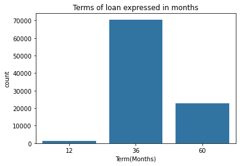

```python
plt.title('Terms of loan expressed in months');
base_color = sb.color_palette()[0]
sb.countplot(data=LoanP, x='Term', color=base_color);
plt.xlabel('Term(Months)')
```

From the plot above, we see that most of the values are in 36 months and the least is 12 month,

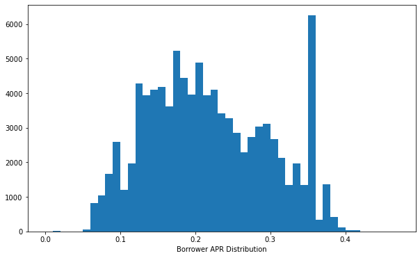

```python
plt.figure(figsize=[10,6])
bins = np.arange(0, LoanP['BorrowerAPR'].max()+0.05,0.01)
plt.hist(x = LoanP['BorrowerAPR'],bins = bins);
plt.xlabel('Borrower APR Distribution')
```

From the diagram above, the maximum APR is within 0.3 and 0.36, while the minimum 0.01 aand 0.02

```python
#for employment status
LoanP['EmploymentStatus'].value_counts()
```

```
Employed         65896
Full-time        24118
Other             2194
Self-employed      993
Part-time          884
Retired            702
Not employed        67
Not available       29
Name: EmploymentStatus, dtype: int64
```

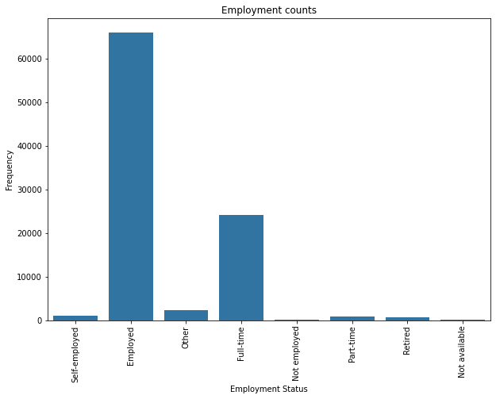

```python
plt.figure(figsize=(10,7))
based_color = sb.color_palette()[0]
#sb.countplot(x=LoanP ['Term']);
sb.countplot(x=LoanP ['EmploymentStatus'],color=base_color);
plt.xticks(rotation=90)
plt.xlabel('Employment Status')
plt.ylabel('Frequency')
plt.title('Employment counts');
```

The above diagram shows that those that are employed tend to borrow more than hose that are unemployed.

For loan status

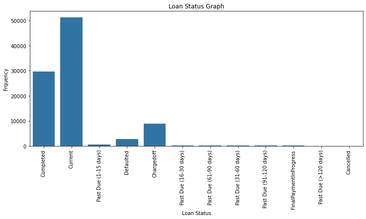

```python
plt.figure(figsize=[12,5])
base_color=sb.color_palette()[0]
sb.countplot(data=LoanP, x='LoanStatus',color=base_color)
plt.xticks(rotation=90)
plt.xlabel('Loan Status')
plt.ylabel('Frquency')
```

DebtToIncomeRatio

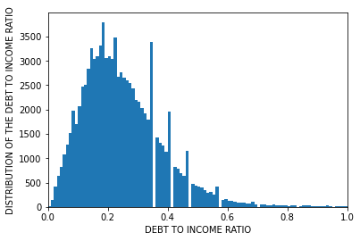

```python
bins = np.arange(LoanP.DebtToIncomeRatio.min(), LoanP.DebtToIncomeRatio.max()+0.01, 0.01)
plt.hist(data=LoanP, x='DebtToIncomeRatio', bins=bins);
plt.xlim(0,1);
plt.xlabel('DEBT TO INCOME RATIO');
plt.ylabel('DISTRIBUTION OF THE DEBT TO INCOME RATIO');
```

This diagram shows a unimodal distribution which is slightly skewed

Sixth varaiables which is occupation

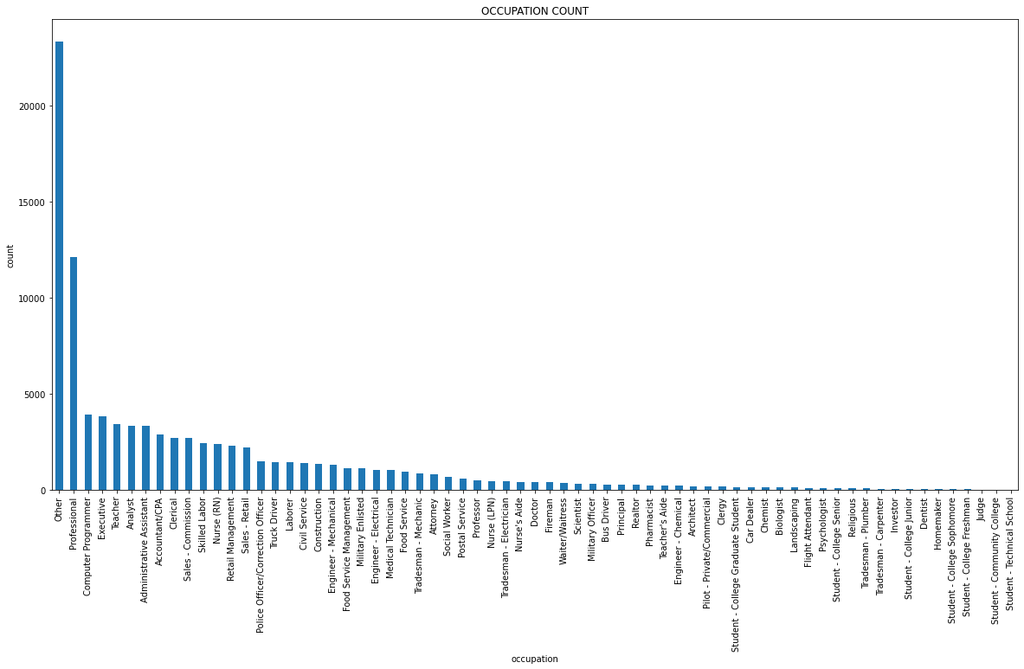

```python
plt.subplots(figsize = [20,10])
based_color = sb.color_palette()[0]
LoanP.Occupation.value_counts().plot(kind='bar', color = based_color);
plt.xlabel('occupation')
plt.ylabel('count')
plt.title('OCCUPATION COUNT');
```

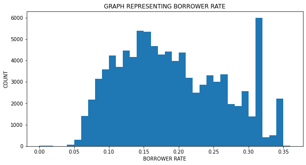

```python
#plotting histogram
bins = np.arange(0,LoanP['BorrowerRate'].max()+0.01,0.01)
plt.figure(figsize=[10,5])
plt.hist(x='BorrowerRate',data=LoanP, bins=bins)
plt.xlabel('BORROWER RATE')
plt.ylabel('COUNT')
plt.title('GRAPH REPRESENTING BORROWER RATE')
```

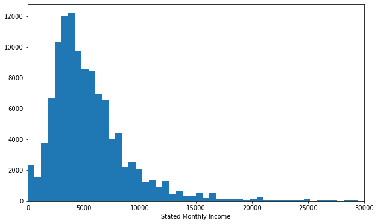

```python
bins = np.arange(0, LoanP['StatedMonthlyIncome'].max()+600,600)
plt.figure(figsize=[10,6])
plt.hist(x='StatedMonthlyIncome', data=Loan, bins=bins);
plt.xlim(0,30000);
plt.xlabel('Stated Monthly Income');
```

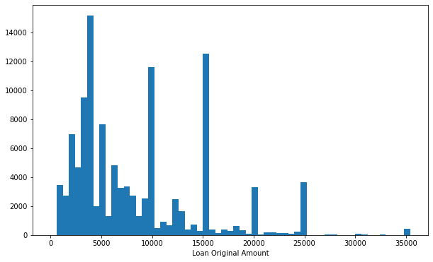

```python
bins = np.arange(0, LoanP['LoanOriginalAmount'].max()+600,600)
plt.figure(figsize=[10,6])
plt.hist(x='LoanOriginalAmount', data=Loan, bins=bins);
plt.xlabel('Loan Original Amount');
```

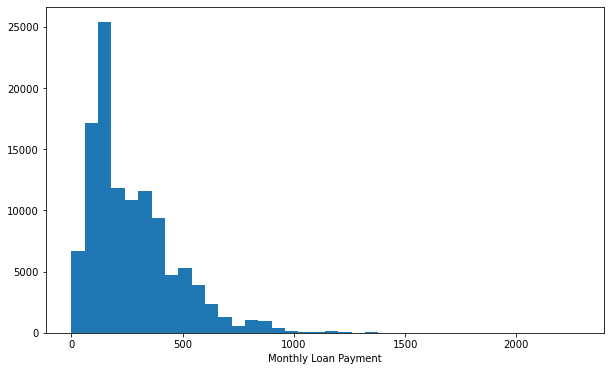

```python
bins = np.arange(0, LoanP['MonthlyLoanPayment'].max()+60,60)
plt.figure(figsize=[10,6])
plt.hist(x='MonthlyLoanPayment', data=Loan, bins=bins);
plt.xlabel('Monthly Loan Payment');
```

## Bivariate Exploration

```python
num_var = ['Term', 'BorrowerAPR', 'BorrowerRate', 'StatedMonthlyIncome', 'LoanOriginalAmount', 'MonthlyLoanPayment', 'DebtToIncomeRatio']
cat_var = ['IncomeRange', 'EmploymentStatus', 'LoanStatus', 'Occupation']
```

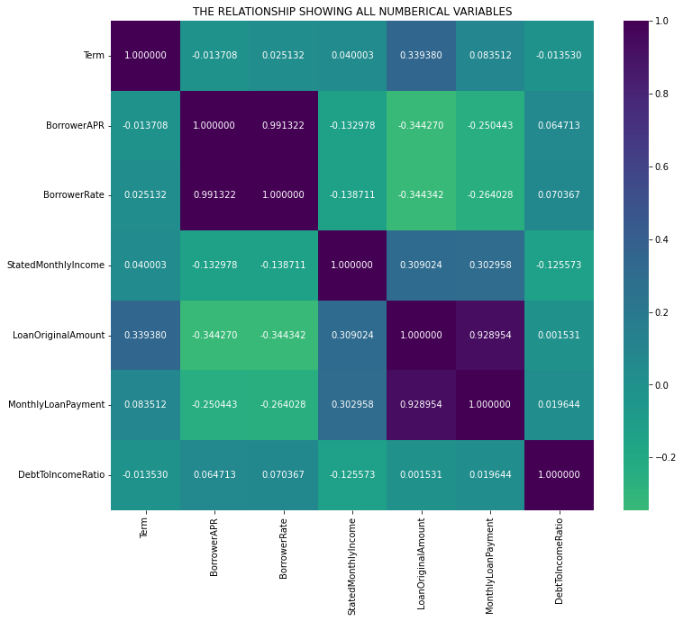

```python
#plot for correlation
plt.figure(figsize = (12,10))
sb.heatmap(LoanP[num_var].corr(), annot = True, fmt = '3f',
           cmap = 'viridis_r', center = 0);
plt.title('THE RELATIONSHIP SHOWING ALL NUMBERICAL VARIABLES')
plt.show()
```

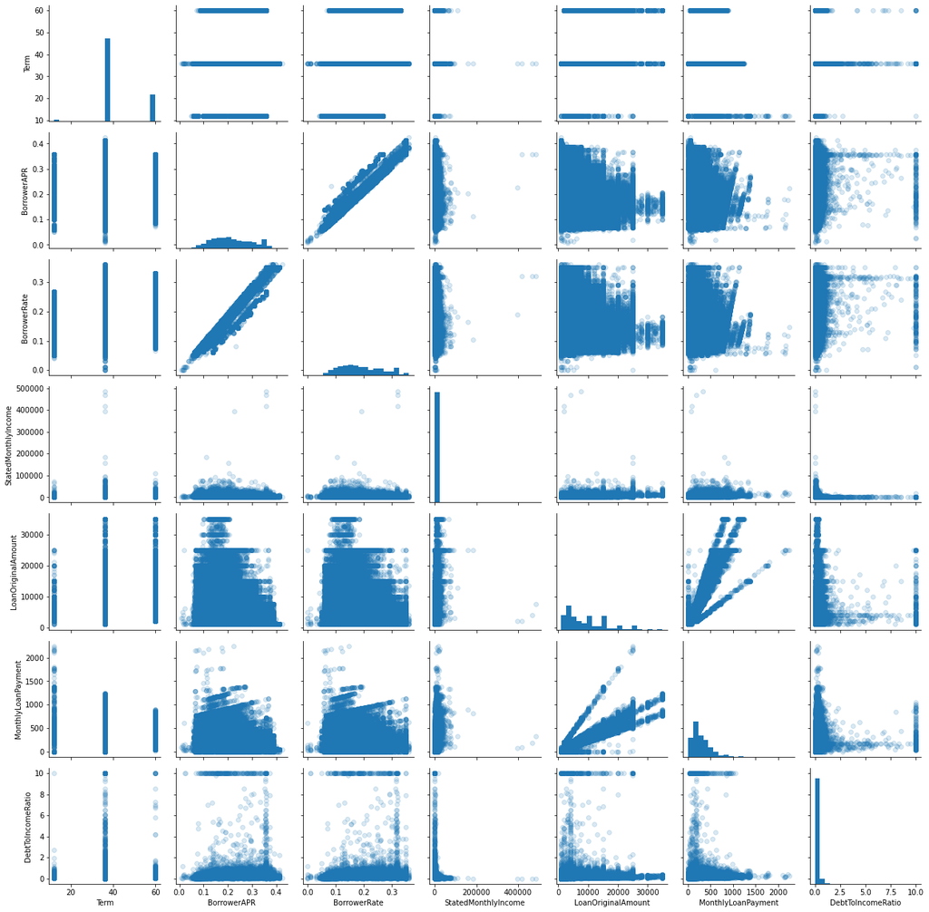

```python
# plot matrix: sample so that plots are clearer and
# they render faster
g = sb.PairGrid(data = LoanP, vars=num_var);
g = g.map_diag(plt.hist, bins=20)
g.map_offdiag(plt.scatter, alpha=1/6)
```

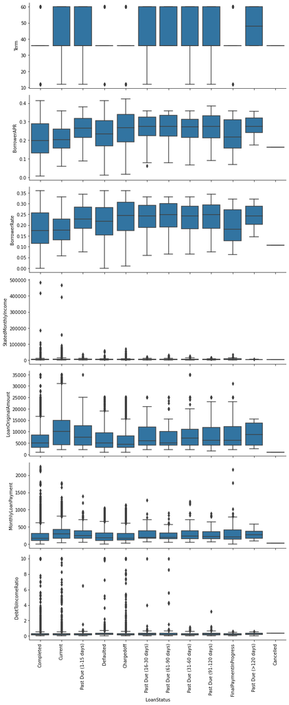

```python
def boxplott(x, y, **kwargs):
    """ Quick hack for creating box plots with seaborn's PairGrid. """
    color = sb.color_palette()[0]
    sb.boxplot(x, y, color=color)
    plt.xticks(rotation=90);

plt.figure(figsize = (10, 10))
g = sb.PairGrid(data = LoanP, y_vars = num_var, x_vars = 'LoanStatus',
                size = 3, aspect = 3)
g.map(boxplott);
```

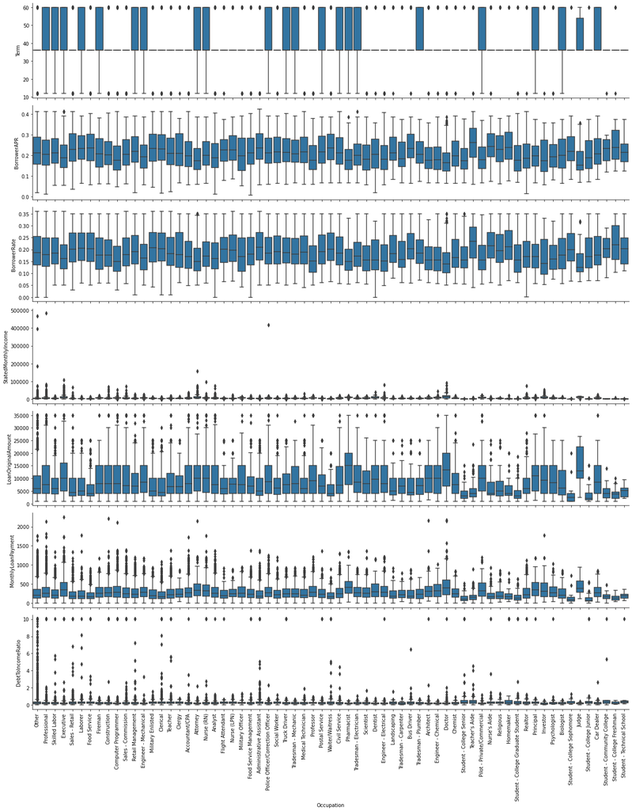

```python
plt.figure(figsize = (30,10))
nv = sb.PairGrid(data = LoanP, y_vars = num_var, x_vars = 'Occupation',
                size = 3, aspect = 6)
nv.map(boxplott);
```

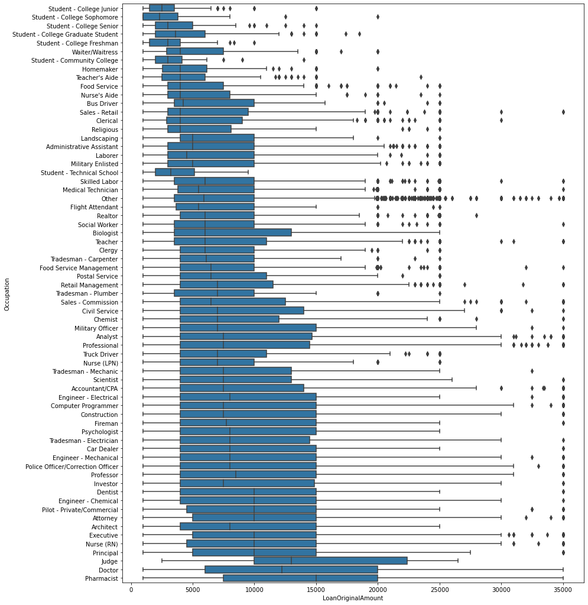

```python
plt.figure(figsize=[14,18])
color=sb.color_palette()[0]
order = LoanP.groupby(by=['Occupation'])['LoanOriginalAmount'].median().sort_values().iloc[::1].index
sb.boxplot(data=Loan,y='Occupation',x='LoanOriginalAmount',color=color,order=order)
```

From the graph, it was observed that the pharmacist takes the highest loan amount.

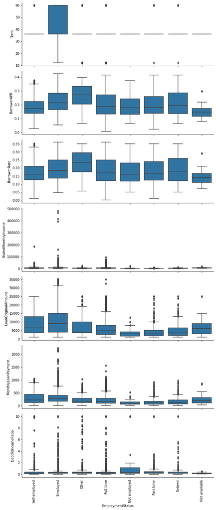

```python
plt.figure(figsize = (20,10))
nv = sb.PairGrid(LoanP, y_vars = num_var, x_vars = 'EmploymentStatus',
                 size = 3, aspect = 3)
nv.map(boxplott);
```

#### creating a new variable 'status'

```python
LoanP['Status'] = np.where((LoanP['LoanStatus'] == 'Current')|
                          (LoanP['LoanStatus'] == 'Completed')|
                          (LoanP['LoanStatus'] == 'Cancelled'),
                          'Completed', 'Defaulted')
```

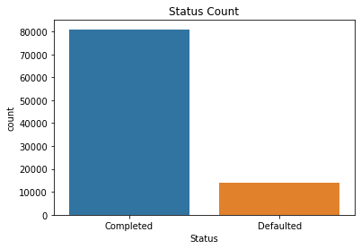

```python
#plot a bar diagram to show count status
sb.countplot(data = LoanP, x = 'Status');
plt.xlabel('Status')
plt.ylabel('count')
plt.title('Status Count');
```

[output not shown]

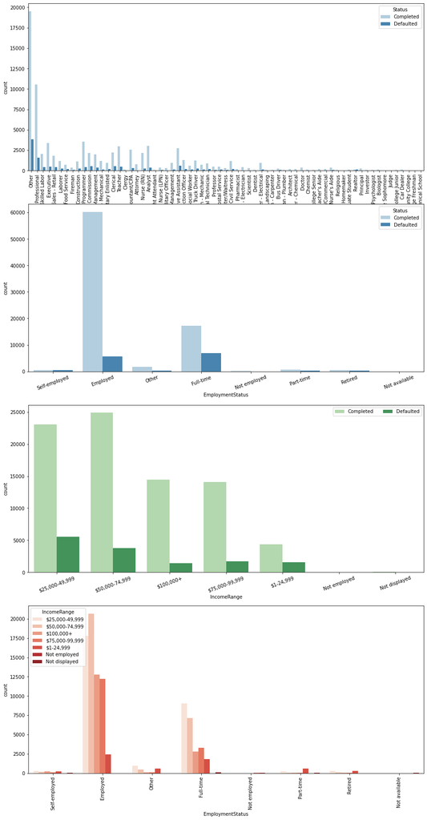

```python
plt.figure(figsize = (15,30))
#subplot 1: IncomingRange vs LoanStatus

plt.subplot(4,1,1)
sb.countplot(data = LoanP, x = 'Occupation', hue = 'Status', palette = 'Blues')
plt.xticks(rotation = 90)

#subplot 2: LoanStatus vs EmploymentStatus
ax = plt.subplot(4,1,2)
sb.countplot(data = LoanP, x = 'EmploymentStatus', hue = 'Status', palette = 'Blues')
plt.xticks(rotation = 20)

#subplot 3:
ax = plt.subplot(4,1,3)
sb.countplot(data = LoanP, x = 'IncomeRange', hue = 'Status', palette = 'Greens')
#rearrange the lengend to remove overlapping
ax.legend(loc = 1, ncol = 2);
plt.xticks(rotation = 20)

#subplot4: EmploymentStatus vs IncomeRange
ax = plt.subplot(4,1,4)
sb.countplot(data = LoanP, x = 'EmploymentStatus', hue = 'IncomeRange', palette = 'Reds')
plt.xticks(rotation = 90)
```

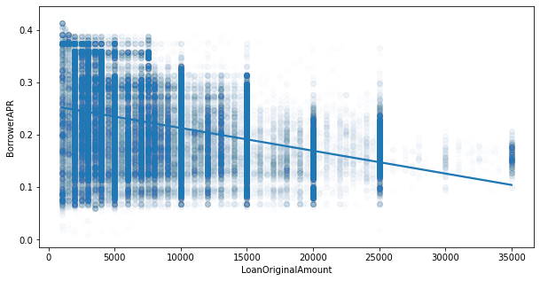

```python
#Relationship between LoanOriginalAmount and BorrowerRate
plt.figure(figsize = [10,5])
sb.regplot(data = LoanP, x = 'LoanOriginalAmount', y = 'BorrowerAPR', scatter_kws={'alpha':0.01});
```

The relation between the two graph is not a strong negative.

## Multivariate Exploration

The relationship betwwen EmploymentStatus and BorrowerAPR and Status

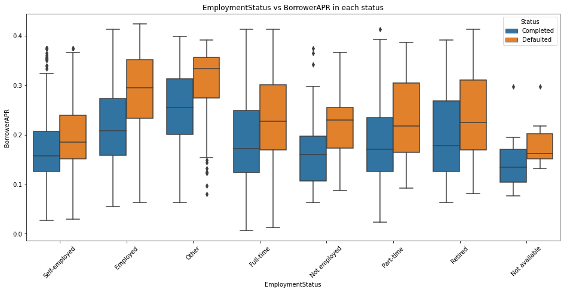

```python
#EmploymentStatus vs BorrowerAPR
plt.figure(figsize=[16,7])
sb.boxplot(data=LoanP, x='EmploymentStatus', y='BorrowerAPR', hue='Status');
plt.title('EmploymentStatus vs BorrowerAPR in each status');
plt.xlabel('EmploymentStatus');
plt.ylabel('BorrowerAPR');
plt.xticks(rotation = 45);
```

[figure not shown]

```python
plt.figure(figsize=[10,7])
sb.pointplot(data=LoanP, x='EmploymentStatus', y='BorrowerAPR', hue='Status', linestyles="");
plt.title('The relationship between EmploymentStatus, BorrowerAPR and Loan Status');
plt.xlabel('Loan Status');
plt.ylabel('BorrowerAPR');
plt.xticks(rotation = 45);
plt.legend(ncol=3);
```

The graph shows that the Borrower APR is higher in defaulter

Relationship between the Term and Loan OriginalAmount and Status

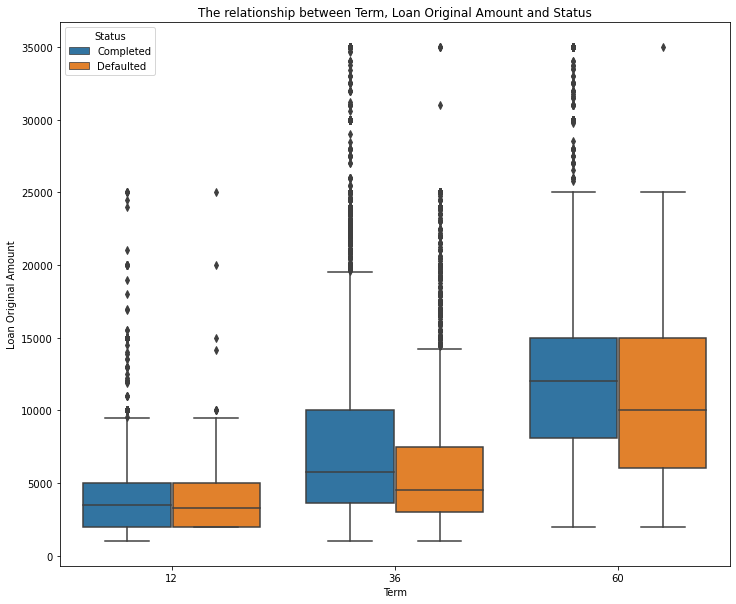

```python
plt.figure(figsize=[12,10])
sb.boxplot(data=LoanP, x='Term', y='LoanOriginalAmount',hue='Status');
plt.xlabel('Term');
plt.ylabel('Loan Original Amount');
plt.title('The relationship between Term, Loan Original Amount and Status');
```

Relationship between Income Range and Loan Original Amount and Term

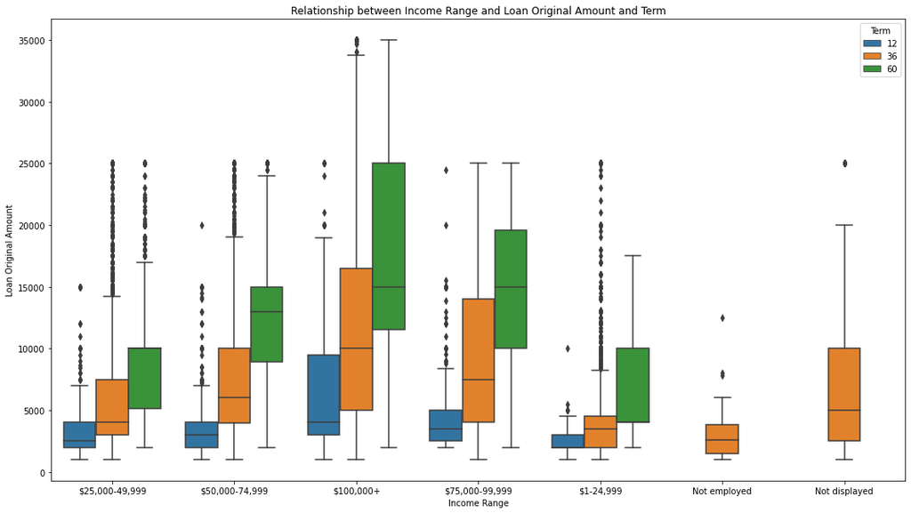

```python
plt.figure(figsize=[18,10])
sb.boxplot(data=LoanP, x='IncomeRange', y='LoanOriginalAmount',hue='Term');
plt.xlabel('Income Range');
plt.ylabel('Loan Original Amount');
plt.title('Relationship between Income Range and Loan Original Amount and Term');
```

Employment status and Borrower Rate vs status

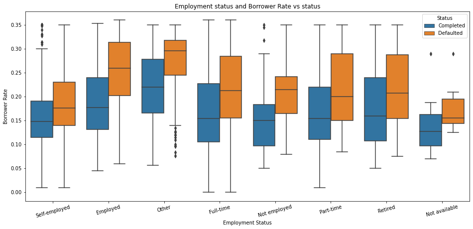

```python
plt.figure(figsize=[16,7])
sb.boxplot(data=LoanP, x='EmploymentStatus', y='BorrowerRate',hue='Status');
plt.xlabel('Employment Status');
plt.ylabel('Borrower Rate');
plt.title('Employment status and Borrower Rate vs status');
plt.xticks(rotation = 15);
```

### Talk about some of the relationships you observed in this part of the investigation. Were there features that strengthened each other in terms of looking at your feature(s) of interest?

I observed that the borrower rate for defaulter is high n the employment status group Also, the loan original amount tend to increase at 60 months in terms of income range.

### Were there any interesting or surprising interactions between features?

The most interesting interraction is that each term, the loan original amount increased the mediana of 36 and 60 months term increased more than 12 months.

## Conclusions

The prosper loan project includes 113937 loans wiith 81 variables which are the coulums. The dataset is a big one which at first was diffcult to understand. With visual analyzing, i was able to know the varaibles, to understand the general idea, structure and datatype. Since the data contain some null values, I had to eliminate before exploring, then visualizations.

In bivariate analysis, the relationship among the variables are explored. I observed that monthly loan payment has a strong positive relationshipwith the loan original amount. The loan original amount is positively correlated with monthly income. The borrowerAPR has a strong positive relationship with the Borrow Rate which is a linear trend.

Also, i performed a multivariate analysis to study various relation between status and various variables. From the diagram, i observed that the loan original amount tends to increase for every income range. The borrower rate for defaulter is highfor all employment status.